# The Impact of Income and Substance Use on Health Outcomes in US Counties

The boxplot of sleep differences reveals the spread and presence of outliers. Most counties have sleep differences ranging from approximately -5 to +5 percentage points, with a few extreme values exceeding ±8 percentage points. The presence of mild outliers suggests that while most counties experienced small changes, a few had more dramatic shifts in sleep deprivation rates.Overall, these visualizations confirm that the distribution of sleep differences is approximately normal, justifying the use of parametric statistical tests such as a paired t-test to determine whether the observed mean difference is statistically significant.

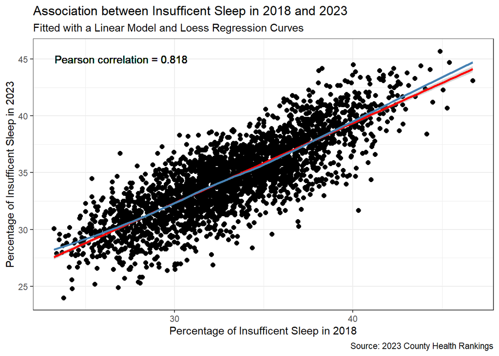

```r
sleep_cor <- str_glue("Pearson correlation = ", round_half_up(cor(slp$insufficent_sleep_2018, slp$insufficent_sleep_2023), 3))

ggplot(slp, aes(x = insufficent_sleep_2018, y = insufficent_sleep_2023)) + geom_point(size = 2) +
  geom_smooth(method = "lm", formula = y ~ x, col = "red", se = TRUE) +
  geom_smooth(method = "loess", formula = y~x, col = "steelblue", se = FALSE) + theme_bw() +
  geom_text(label = sleep_cor, x = 27, y = 45 ) +
  labs(title = "Association between Insufficent Sleep in 2018 and 2023",
       subtitle = "Fitted with a Linear Model and Loess Regression Curves",
       x = "Percentage of Insufficent Sleep in 2018",
       caption = "Source: 2023 County Health Rankings",
       y = "Percentage of Insufficent Sleep in 2023")
```

The scatterplot shows the association between insufficient sleep prevalence in 2018 and 2023 across U.S. counties, with both a linear regression model (red line) and a loess regression curve (blue line) fitted to the data. The Pearson correlation coefficient of 0.818 indicates a strong positive linear relationship, suggesting that counties with higher insufficient sleep percentages in 2018 tended to also have higher insufficient sleep percentages in 2023. The linear regression model (red line) closely follows the trend of the data, showing a consistent, positive association between the two years. The loess curve (blue line) aligns well with the linear model, suggesting that the relationship remains approximately linear across the range of insufficient sleep percentages, with no major deviations or non-linear trends.

Despite the strong correlation, there is some spread in the data, indicating county-level variability in sleep trends. While most counties followed a similar trajectory, some experienced larger increases or decreases in insufficient sleep prevalence than expected. This variation could be influenced by differences in public health policies, socioeconomic conditions, or lifestyle factors across regions.

The strong correlation suggests that insufficient sleep trends are persistent over time, with counties that had high sleep deprivation rates in 2018 continuing to report high rates in 2023. However, individual county-level differences highlight the need for further exploration into factors driving changes in sleep behavior over time.

## 14.3 Model

```r
t.test(slp$sleep_diff, data = smoke, conf.int = TRUE, conf.level = 0.90) %>% tidy() %>% gt() %>% fmt_number(decimals = 2)
```

| estimate | statistic | p.value | parameter | conf.low | conf.high | method | alternative |
| --- | --- | --- | --- | --- | --- | --- | --- |
| 1.41 | 31.58 | 0.00 | 2,767.00 | 1.33 | 1.48 | One Sample t-test | two.sided |

A one-sample t-test was conducted to determine whether the mean change in insufficient sleep prevalence between 2018 and 2023 was statistically significant. The test produced a highly significant result (p < 0.001), indicating that the observed mean difference is unlikely to be due to random chance. The estimated mean difference in insufficient sleep percentages is 1.41 percentage points, meaning that, on average, counties experienced a 1.41% increase in the proportion of adults reporting insufficient sleep from 2018 to 2023. The 90% confidence interval [1.33, 1.48] suggests that the true mean difference in the population likely falls within this range, further reinforcing the significance of the result.

The t-statistic of 31.58 with 2,767 degrees of freedom is very large, providing strong evidence against the null hypothesis that there is no change in sleep deprivation rates over time. Since the test was two-sided, it accounts for the possibility of both increases and decreases, though in this case, the positive estimate confirms an upward trend in insufficient sleep prevalence.

These findings provide statistically significant evidence that insufficient sleep rates have increased in U.S. counties between 2018 and 2023. While the observed increase of 1.41 percentage points may seem small, it represents a consistent trend across counties, potentially reflecting broader societal changes such as increased stress levels, lifestyle shifts, or declining sleep hygiene practices.

## 14.4 Conclusions

One limitation of this analysis is missing data that is likely “Missing Not at Random” (MNAR). Notably, all 58 counties in California lacked insufficient sleep data for 2018, meaning California was entirely excluded from the analysis. Since California represents a significant portion of the U.S. population, its absence may introduce regional bias into the findings.

A potential next step for future research would be to explore underlying factors contributing to changes in sleep deprivation, such as economic stress, work-life balance, increased screen time, or public health interventions. Additionally, controlling for confounding variables—such as income levels, employment status, and regional differences in healthcare access—could provide deeper insight into the drivers of increasing sleep deprivation. Further analysis could also compare urban vs. rural counties to assess whether geographic location influences sleep trends over time.